# 건설 사고 시 사망의 요인 분석

202055127 박세영 202055138 우지민

```python
import numpy as np
import pandas as pd
import scipy as sp
from scipy import stats

# 그래프를 그리기 위한 라이브러리
from matplotlib import pyplot as plt
import seaborn as sns
sns.set()

import statsmodels.formula.api as smf
import statsmodels.api as sm
import warnings
from statsmodels.graphics.mosaicplot import mosaic
warnings.filterwarnings("ignore")
# 표시 자릿수 지정
%precision 3
# 그래프를 주피터 노트북에 그리기 위한 설정
%matplotlib inline

#국토안전관리원_건설안전사고 발생현황(사고일,프로젝트,재해자특성)_20210404 불러오기
data = pd.read_csv("data.csv",encoding='CP949')
```

1. 서론
   - 주제
   - 데이터 분석
1. 본론
   - 데이터 전처리
   - 데이터 시각화
   - 모델 생성
   - 모델 성능 test
1. 결론
   - 분석 결과
   - 한계 및 보완할 점
   - 시사점

```
참고문헌
```

# 서론

## 1-1. 주제

- 건설사고 발생 시 사망할 확률에 영향을 미치는 요인이 무엇일까?
- **날씨, 계절** 과 같은 환경적인 요인이 사망할 확률에 큰 영향을 줄 것으로 예상.

## 1-2. 데이터 분석

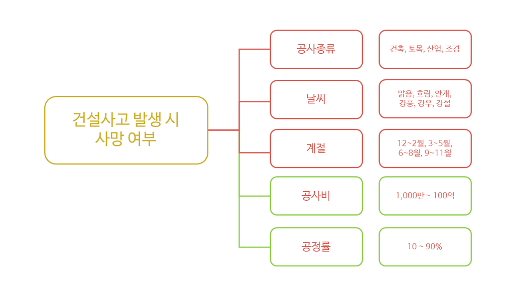

# 본론

## 2-1. 데이터 전처리

```python
data0 = data[['공정율', '날씨','공사종류','공사비','사망자','사고일시']]
data1 = data0[data0.공사비 !="분류불능"]
```

```python
data1
```

|  | 공정율 | 날씨 | 공사종류 | 공사비 | 사망자 | 사고일시 |
| --- | --- | --- | --- | --- | --- | --- |
| 0 | 30~39% | 맑음 | 토목/상하수도/하수도 | 50억 ~ 100억원 미만 | 1 | 2020-07-05 8:54 |
| 1 | 20~29% | 맑음 | 건축/건축물/업무시설 | 10억 ~ 20억원 미만 | 0 | 2019-07-01 7:10 |
| 2 | 80~89% | 강우 | 건축/건축물/공동주택 | 150억 ~ 200억원 미만 | 0 | 2019-07-01 8:50 |
| 3 | 60~69% | 맑음 | 토목/옹벽 및 절토사면/옹벽 | 1,000억원 이상 | 0 | 2019-07-01 9:30 |
| 4 | 90% 이상 | 맑음 | 토목/터널/철도터널 | 500억 ~ 1,000억원 미만 | 0 | 2019-07-01 10:00 |
| ... | ... | ... | ... | ... | ... | ... |
| 6958 | 20~29% | 맑음 | 건축/건축물/업무시설 | 300억 ~ 500억원 미만 | 0 | 2021-04-01 15:44 |
| 6959 | 60~69% | 맑음 | 토목/도로/도로 | 300억 ~ 500억원 미만 | 0 | 2021-04-01 16:40 |
| 6960 | 70~79% | 맑음 | 토목/상하수도/기타 | 2억 ~ 3억원 미만 | 0 | 2021-04-02 11:20 |
| 6961 | 30~39% | 흐림 | 토목/터널/지하차도 | 200억 ~ 300억원 미만 | 1 | 2021-04-02 13:45 |
| 6962 | 50~59% | 강우 | 토목/터널/철도터널 | 1,000억원 이상 | 0 | 2021-04-03 10:45 |

6914 rows × 6 columns

```python
#공사종류별 4가지 (건축, 토목, 조경, 산업)로 분류
data1['Type'] = data1['공사종류'].apply(lambda x : str(x)[0:2])
```

```python
#공사종류 이름 바꾸기
Type_map = {'건축': 'construction', '토목': 'civil engineering', '조경' : 'landscaping', '산업': 'industrial environment'}
data1['type'] = data1['Type'].map(Type_map)
```

```python
#공사비 mapping
gongsa_map = {'1,000만원 미만' : 10, '1,000만 ~ 2,000만원 미만' : 15, '2,000만 ~ 4,000만원 미만' : 30, '4,000만 ~ 1억원 미만' : 70,
              '1억 ~ 2억원 미만' : 150 ,'2억 ~ 3억원 미만':250,'3억 ~ 5억원 미만':400,'5억 ~ 10억원 미만':750,'10억 ~ 20억원 미만': 1500,
              '20억 ~ 50억원 미만': 3500,'50억 ~ 100억원 미만':7500,'100억 ~ 150억원 미만':12500,'150억 ~ 200억원 미만':17500,
              '200억 ~ 300억원 미만':25000,'300억 ~ 500억원 미만': 40000, '500억 ~ 1,000억원 미만': 75000,
              '1,000억원 이상': 100000}
data1['cost'] = data1['공사비'].map(gongsa_map)
```

```python
#날씨 매핑
weather_map = {'맑음': "sunny", "흐림":"cloudy","안개":"foggy","강설":"snow","강우":"rainy","강풍":"windy"}
data1['weather2'] = data1['날씨'].map(weather_map)
```

```python
#날씨 매핑 (맑음, 맑지않음)
weather_map2 = {'맑음': "sunny", "흐림":"not sunny","안개":"not sunny","강설":"not sunny","강우":"not sunny","강풍":"not sunny"}
data1['weather3'] = data1['날씨'].map(weather_map2)
```

```python
#극단적인 값 제거
data1 = data1[data1.사망자 != 38]
```

```python
#공정율 수치화
data1['process']=pd.to_numeric(data1['공정율'].apply(lambda x : str(x)[0:2]))
```

```python
#사고일시-월 만 추출
data1['month'] = data1['사고일시'].apply(lambda x : str(x)[5:7])
```

```python
#계절 mapping
season_map = {'12':'winter','01':'winter','02':'winter',
              '03':'spring','04':'spring','05':'spring',
              '06':'summer','07':'summer','08':'summer',
              '09':'autumn','10':'autumn','11':'autumn'}
data1['season'] = data1['month'].map(season_map)
```

```python
#사망여부 column 만들기 (사망 있음 = 1, 사망 없음 = 0)
data1['danger'] = [1 if b >= 1 else 0 for b in data1['사망자']]
```

#### 사망자 수 복제

```python
# 사망자 비율
len(data1[data1['사망자']>=1]) / len(data1)
```

```
0.047
```

```python
len(data1[data1['사망자']>=1])
```

```
324
```

```python
death = data1[data1['사망자']>=1.0]
```

```python
data_copy = []
for i in range(0,19):
    data_copy.append(death)

data_new_copy = pd.concat(data_copy)
data_new = pd.concat([data1, data_new_copy])
```

```python
data_new
```

|  | 공정율 | 날씨 | 공사종류 | 공사비 | 사망자 | 사고일시 | Type | type | cost | weather2 | weather3 | process | month | season | danger |
| --- | --- | --- | --- | --- | --- | --- | --- | --- | --- | --- | --- | --- | --- | --- | --- |
| 0 | 30~39% | 맑음 | 토목/상하수도/하수도 | 50억 ~ 100억원 미만 | 1 | 2020-07-05 8:54 | 토목 | civil engineering | 7500 | sunny | sunny | 30 | 07 | summer | 1 |
| 1 | 20~29% | 맑음 | 건축/건축물/업무시설 | 10억 ~ 20억원 미만 | 0 | 2019-07-01 7:10 | 건축 | construction | 1500 | sunny | sunny | 20 | 07 | summer | 0 |
| 2 | 80~89% | 강우 | 건축/건축물/공동주택 | 150억 ~ 200억원 미만 | 0 | 2019-07-01 8:50 | 건축 | construction | 17500 | rainy | not sunny | 80 | 07 | summer | 0 |
| 3 | 60~69% | 맑음 | 토목/옹벽 및 절토사면/옹벽 | 1,000억원 이상 | 0 | 2019-07-01 9:30 | 토목 | civil engineering | 100000 | sunny | sunny | 60 | 07 | summer | 0 |
| 4 | 90% 이상 | 맑음 | 토목/터널/철도터널 | 500억 ~ 1,000억원 미만 | 0 | 2019-07-01 10:00 | 토목 | civil engineering | 75000 | sunny | sunny | 90 | 07 | summer | 0 |
| ... | ... | ... | ... | ... | ... | ... | ... | ... | ... | ... | ... | ... | ... | ... | ... |
| 6916 | 90% 이상 | 맑음 | 건축/건축물/공동주택 | 1억 ~ 2억원 미만 | 1 | 2021-03-25 15:30 | 건축 | construction | 150 | sunny | sunny | 90 | 03 | spring | 1 |
| 6927 | 10~19% | 맑음 | 건축/건축물/업무시설 | 300억 ~ 500억원 미만 | 1 | 2021-03-26 15:10 | 건축 | construction | 40000 | sunny | sunny | 10 | 03 | spring | 1 |
| 6938 | 60~69% | 맑음 | 토목/도로/도로 | 1,000억원 이상 | 1 | 2021-03-30 8:32 | 토목 | civil engineering | 100000 | sunny | sunny | 60 | 03 | spring | 1 |
| 6953 | 20~29% | 맑음 | 토목/기타/부지조성 | 300억 ~ 500억원 미만 | 1 | 2021-03-31 17:00 | 토목 | civil engineering | 40000 | sunny | sunny | 20 | 03 | spring | 1 |
| 6961 | 30~39% | 흐림 | 토목/터널/지하차도 | 200억 ~ 300억원 미만 | 1 | 2021-04-02 13:45 | 토목 | civil engineering | 25000 | cloudy | not sunny | 30 | 04 | spring | 1 |

13069 rows × 15 columns

## 2-2. 데이터 시각화

- 사망비율 graph로 나타내기_ 공사종류, 날씨, 계절

```python
# 복제된 데이터를 기준으로 사망비율 비교
def graph_ratio(column):

    death_sum = data_new.groupby(column).danger.sum()

    death_count = data_new.groupby(column).danger.count()

    label = data_new.groupby(column).count().index

    N = len(data_new[column].unique())
    index = np.arange(N)

    #총 사망여부
    sum1= []

    for b in label :
        sum1.append(death_sum[b])

    #총 사건 발생 수

    count = []

    for b in label :
        count.append(death_count[b])

    #사망비율

    ratio= []

    for b in range(len(label)):
        ratio2 = sum1[b]/count[b]
        ratio.append(ratio2)

    plt.rcParams["figure.figsize"] = (14,4)

    plt.title(column+' & ratio', fontsize=30)

    plt.ylabel('death ratio', fontsize=18)

    plt.xlabel(column, fontsize=18)

    plt.xticks(index, label, fontsize=15)

    colors = sns.color_palette('hls',len(column))

    return plt.bar(label, ratio, width = 0.3,data = data_new,color=colors), ratio
```

```python
# 기존 데이터를 기준으로 사망비율 비교
def graph_ratio_data1(column):

    death_sum = data1.groupby(column).danger.sum()

    death_count = data1.groupby(column).danger.count()

    label = data1.groupby(column).count().index

    N = len(data1[column].unique())
    index = np.arange(N)

    #총 사망여부
    sum1= []

    for b in label :
        sum1.append(death_sum[b])

    #총 사건 발생 수

    count = []

    for b in label :
        count.append(death_count[b])

    #사망비율

    ratio= []

    for b in range(len(label)):
        ratio2 = sum1[b]/count[b]
        ratio.append(ratio2)

    plt.rcParams["figure.figsize"] = (14,4)

    plt.title(column+' & ratio', fontsize=30)

    plt.ylabel('death ratio', fontsize=18)

    plt.xlabel(column, fontsize=18)

    plt.xticks(index, label, fontsize=15)

    colors = sns.color_palette('hls',len(column))

    return plt.bar(label, ratio, width = 0.3,data = data1,color=colors), ratio
```

```
(<BarContainer object of 4 artists>,
 [0.06357279084551812,
  0.042736757624398075,
  0.02456140350877193,
  0.056338028169014086])
```

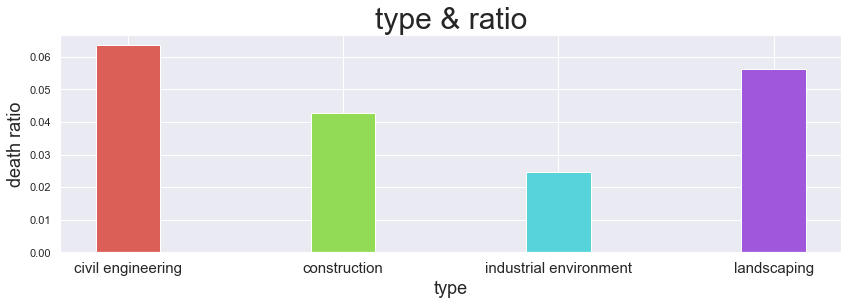

```python
# 공사종류별 사망비율
graph_ratio_data1('type')
```

```python
data1.groupby('type').count()
```

| type | 공정율 | 날씨 | 공사종류 | 공사비 | 사망자 | 사고일시 | Type | cost | weather2 | weather3 | process | month | season | danger |
| --- | --- | --- | --- | --- | --- | --- | --- | --- | --- | --- | --- | --- | --- | --- |
| civil engineering | 1573 | 1573 | 1573 | 1573 | 1573 | 1573 | 1573 | 1573 | 1573 | 1573 | 1573 | 1573 | 1573 | 1573 |
| construction | 4984 | 4984 | 4984 | 4984 | 4984 | 4984 | 4984 | 4984 | 4984 | 4984 | 4984 | 4984 | 4984 | 4984 |
| industrial environment | 285 | 285 | 285 | 285 | 285 | 285 | 285 | 285 | 285 | 285 | 285 | 285 | 285 | 285 |
| landscaping | 71 | 71 | 71 | 71 | 71 | 71 | 71 | 71 | 71 | 71 | 71 | 71 | 71 | 71 |

```python
data1[data1['사망자']>=1].groupby('type').count()
```

| type | 공정율 | 날씨 | 공사종류 | 공사비 | 사망자 | 사고일시 | Type | cost | weather2 | weather3 | process | month | season | danger |
| --- | --- | --- | --- | --- | --- | --- | --- | --- | --- | --- | --- | --- | --- | --- |
| civil engineering | 100 | 100 | 100 | 100 | 100 | 100 | 100 | 100 | 100 | 100 | 100 | 100 | 100 | 100 |
| construction | 213 | 213 | 213 | 213 | 213 | 213 | 213 | 213 | 213 | 213 | 213 | 213 | 213 | 213 |
| industrial environment | 7 | 7 | 7 | 7 | 7 | 7 | 7 | 7 | 7 | 7 | 7 | 7 | 7 | 7 |
| landscaping | 4 | 4 | 4 | 4 | 4 | 4 | 4 | 4 | 4 | 4 | 4 | 4 | 4 | 4 |

```
(<BarContainer object of 4 artists>,
 [0.5758710048949035,
  0.47170855940648876,
  0.3349282296650718,
  0.54421768707483])
```

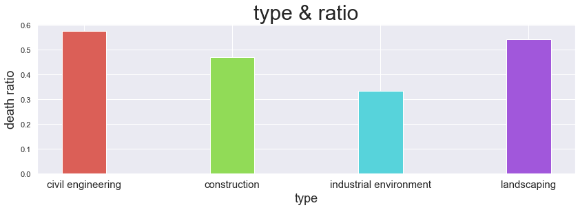

```python
#복제된 데이터로 공사종류별 사망비율 비교

graph_ratio('type')
```

```
(<BarContainer object of 6 artists>,
 [0.045234248788368334,
  0.023809523809523808,
  0.03934426229508197,
  0.03125,
  0.04834360554699538,
  0.05])
```

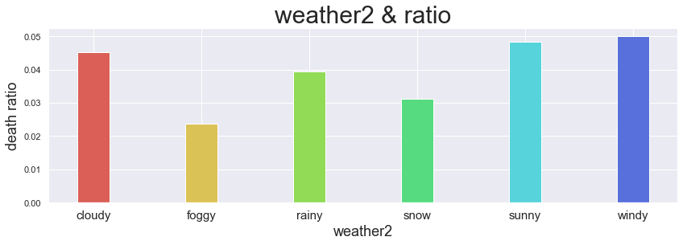

```python
# 날씨별 (6가지 경우) 사망비율
graph_ratio_data1('weather2')
```

```python
data1.groupby('weather2').count()
```

| weather2 | 공정율 | 날씨 | 공사종류 | 공사비 | 사망자 | 사고일시 | Type | type | cost | weather3 | process | month | season | danger |
| --- | --- | --- | --- | --- | --- | --- | --- | --- | --- | --- | --- | --- | --- | --- |
| cloudy | 1238 | 1238 | 1238 | 1238 | 1238 | 1238 | 1238 | 1238 | 1238 | 1238 | 1238 | 1238 | 1238 | 1238 |
| foggy | 126 | 126 | 126 | 126 | 126 | 126 | 126 | 126 | 126 | 126 | 126 | 126 | 126 | 126 |
| rainy | 305 | 305 | 305 | 305 | 305 | 305 | 305 | 305 | 305 | 305 | 305 | 305 | 305 | 305 |
| snow | 32 | 32 | 32 | 32 | 32 | 32 | 32 | 32 | 32 | 32 | 32 | 32 | 32 | 32 |
| sunny | 5192 | 5192 | 5192 | 5192 | 5192 | 5192 | 5192 | 5192 | 5192 | 5192 | 5192 | 5192 | 5192 | 5192 |
| windy | 20 | 20 | 20 | 20 | 20 | 20 | 20 | 20 | 20 | 20 | 20 | 20 | 20 | 20 |

```
(<BarContainer object of 2 artists>,
 [0.04241719930273097, 0.04834360554699538])
```

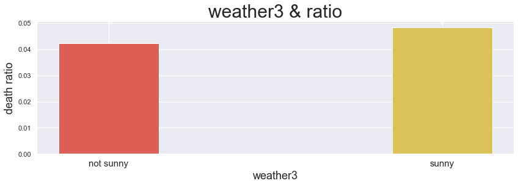

```python
# 날씨별 (3가지 경우) 사망비율
graph_ratio_data1('weather3')
```

```
(<BarContainer object of 4 artists>,
 [0.5200381679389313,
  0.4819277108433735,
  0.4845946754412205,
  0.48620236530880423])
```

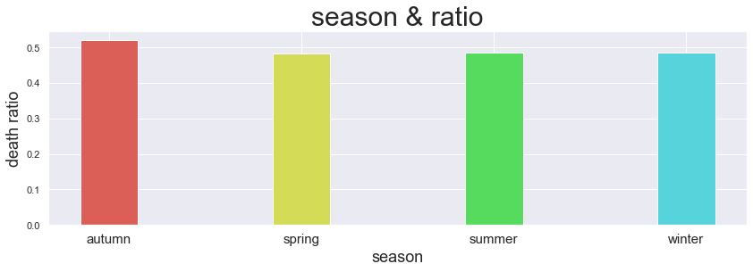

```python
# 계절별 사망비율
graph_ratio('season')
```

- 로지스틱 회귀곡선 - 공사비, 공정율

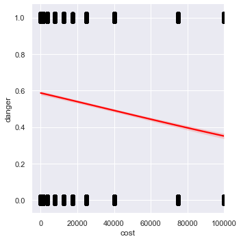

```python
# 공사비와 사망여부 - 로지스틱 회귀곡선
sns.lmplot(x = "cost", y = "danger",
           data = data_new,
           logistic= True,
           scatter_kws = {"color": "black"},
           line_kws    = {"color": "red"},
           x_jitter = 0.1, y_jitter = 0.02)
```

```
(<BarContainer object of 17 artists>,
 [0.6349206349206349,
  0.4878048780487805,
  0.35973493215525404,
  0.4101326899879373,
  0.43795620437956206,
  0.35353535353535354,
  0.794392523364486,
  0.6944444444444444,
  0.41899441340782123,
  0.578386605783866,
  0.724233983286908,
  0.5598455598455598,
  0.6167400881057269,
  0.7563025210084033,
  0.3970223325062035,
  0.5673758865248227,
  0.6648936170212766])
```

[figure not shown]

```python
#공사비를 막대그래프로 시각화
graph_ratio('공사비')
```

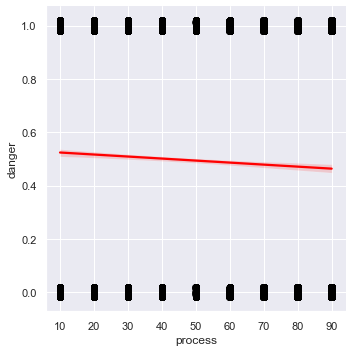

```python
# 공정율과 사망여부 - 로지스틱 회귀곡선
sns.lmplot(x = "process", y = "danger",
           data = data_new,
           logistic= True,
           scatter_kws = {"color": "black"},
           line_kws    = {"color": "red"},
           x_jitter = 0.1, y_jitter = 0.02)
```

## 2-3. 모델 생성

#### 단일변수 모델 aic 비교

```python
model_C = smf.glm("danger~cost", data = data_new,family=sm.families.Binomial()).fit()
model_P = smf.glm("danger~process", data = data_new,family=sm.families.Binomial()).fit()
model_W = smf.glm("danger~weather2", data = data_new,family=sm.families.Binomial()).fit()
model_T = smf.glm("danger~type", data = data_new,family=sm.families.Binomial()).fit()
model_S = smf.glm("danger~season", data = data_new,family=sm.families.Binomial()).fit()
```

```python
model_C.aic,model_W.aic,model_P.aic,model_T.aic,model_S.aic
```

```
(17628.461053604835,
 18097.349938370837,
 18096.63047972389,
 17968.69697196286,
 18110.000360827667)
```

```python
model_null = smf.glm("danger~1", data = data_new,family=sm.families.Binomial()).fit()
model_CT = smf.glm("danger~cost+type", data = data_new,family=sm.families.Binomial()).fit()
model_CTP = smf.glm("danger~cost+type+process", data = data_new,family=sm.families.Binomial()).fit()
model_CTPW = smf.glm("danger~cost+type+process+weather2", data = data_new,family=sm.families.Binomial()).fit()
model_CTPWS = smf.glm("danger~cost+type+process+weather2+season", data = data_new,family=sm.families.Binomial()).fit()
model_null.aic,model_C.aic,model_CT.aic,model_CTP.aic,model_CTPW.aic,model_CTPWS.aic
```

```
(18118.5718970707,
 17628.461053604835,
 17538.041025329054,
 17516.063755796116,
 17502.147448718584,
 17502.598693447508)
```

```python
model_CTPW.summary()
```

Generalized Linear Model Regression Results

| Dep. Variable: | danger | No. Observations: | 13069 |
| --- | --- | --- | --- |
| Model: | GLM | Df Residuals: | 13058 |
| Model Family: | Binomial | Df Model: | 10 |
| Link Function: | logit | Scale: | 1.0000 |
| Method: | IRLS | Log-Likelihood: | -8740.1 |
| Date: | Thu, 10 Jun 2021 | Deviance: | 17480. |
| Time: | 17:48:36 | Pearson chi2: | 1.31e+04 |
| No. Iterations: | 4 |  |  |
| Covariance Type: | nonrobust |  |  |

|  | coef | std err | z | P>\|z\| | [0.025 | 0.975] |
| --- | --- | --- | --- | --- | --- | --- |
| Intercept | 0.7591 | 0.063 | 11.974 | 0.000 | 0.635 | 0.883 |
| type[T.construction] | -0.3702 | 0.041 | -8.953 | 0.000 | -0.451 | -0.289 |
| type[T.industrial environment] | -0.6778 | 0.112 | -6.027 | 0.000 | -0.898 | -0.457 |
| type[T.landscaping] | -0.3957 | 0.171 | -2.320 | 0.020 | -0.730 | -0.061 |
| weather2[T.foggy] | -0.6791 | 0.166 | -4.095 | 0.000 | -1.004 | -0.354 |
| weather2[T.rainy] | -0.0320 | 0.099 | -0.324 | 0.746 | -0.226 | 0.162 |
| weather2[T.snow] | -0.5501 | 0.301 | -1.826 | 0.068 | -1.140 | 0.040 |
| weather2[T.sunny] | 0.0252 | 0.048 | 0.531 | 0.595 | -0.068 | 0.118 |
| weather2[T.windy] | 0.0240 | 0.326 | 0.073 | 0.941 | -0.616 | 0.664 |
| cost | -9.185e-06 | 4.51e-07 | -20.386 | 0.000 | -1.01e-05 | -8.3e-06 |
| process | -0.0033 | 0.001 | -5.110 | 0.000 | -0.005 | -0.002 |

## 2-4. 모델 성능 Test

```python
exp_val_1 = data_new[['cost','type','process','weather2']]
data_new['predicted1']=model_CT.predict(exp_val_1)
data_new['danger_pre1'] = [0 if b<=0.5 else 1 for b in data_new['predicted1']]
data_nonpre1 = data_new[data_new['danger_pre1'] != data_new['danger']]
data_nonpre1
```

|  | 공정율 | 날씨 | 공사종류 | 공사비 | 사망자 | 사고일시 | Type | type | cost | weather2 | weather3 | process | month | season | danger | predicted1 | danger_pre1 |
| --- | --- | --- | --- | --- | --- | --- | --- | --- | --- | --- | --- | --- | --- | --- | --- | --- | --- |
| 1 | 20~29% | 맑음 | 건축/건축물/업무시설 | 10억 ~ 20억원 미만 | 0 | 2019-07-01 7:10 | 건축 | construction | 1500 | sunny | sunny | 20 | 07 | summer | 0 | 0.557700 | 1 |
| 2 | 80~89% | 강우 | 건축/건축물/공동주택 | 150억 ~ 200억원 미만 | 0 | 2019-07-01 8:50 | 건축 | construction | 17500 | rainy | not sunny | 80 | 07 | summer | 0 | 0.521081 | 1 |
| 7 | 30~39% | 흐림 | 토목/기타 | 50억 ~ 100억원 미만 | 0 | 2019-07-01 11:15 | 토목 | civil engineering | 7500 | cloudy | not sunny | 30 | 07 | summer | 0 | 0.632369 | 1 |
| 9 | 90% 이상 | 흐림 | 건축/건축물/공장 | 2,000만 ~ 4,000만원 미만 | 0 | 2019-07-01 13:30 | 건축 | construction | 30 | cloudy | not sunny | 90 | 07 | summer | 0 | 0.561040 | 1 |
| 10 | 30~39% | 흐림 | 건축/건축물/교육연구시설 | 100억 ~ 150억원 미만 | 0 | 2019-07-01 13:40 | 건축 | construction | 12500 | cloudy | not sunny | 30 | 07 | summer | 0 | 0.532567 | 1 |
| ... | ... | ... | ... | ... | ... | ... | ... | ... | ... | ... | ... | ... | ... | ... | ... | ... | ... |
| 6723 | 90% 이상 | 강우 | 건축/건축물/업무시설 | 1,000억원 이상 | 1 | 2021-03-01 6:18 | 건축 | construction | 100000 | rainy | not sunny | 90 | 03 | spring | 1 | 0.337160 | 0 |
| 6799 | 80~89% | 맑음 | 산업환경설비/산업생산시설/석유화학공장 | 1,000억원 이상 | 1 | 2021-03-11 8:50 | 산업 | industrial environment | 100000 | sunny | sunny | 80 | 03 | spring | 1 | 0.268767 | 0 |
| 6874 | 10% 미만 | 맑음 | 건축/건축물/공장 | 1,000억원 이상 | 1 | 2021-03-19 9:25 | 건축 | construction | 100000 | sunny | sunny | 10 | 03 | spring | 1 | 0.337160 | 0 |
| 6927 | 10~19% | 맑음 | 건축/건축물/업무시설 | 300억 ~ 500억원 미만 | 1 | 2021-03-26 15:10 | 건축 | construction | 40000 | sunny | sunny | 10 | 03 | spring | 1 | 0.469290 | 0 |
| 6938 | 60~69% | 맑음 | 토목/도로/도로 | 1,000억원 이상 | 1 | 2021-03-30 8:32 | 토목 | civil engineering | 100000 | sunny | sunny | 60 | 03 | spring | 1 | 0.423086 | 0 |

5578 rows × 17 columns

```python
#모델 예측 정확도
1-len(data_nonpre1)/len(data_new)
```

```
0.573
```

```python
#사망확률 낮은 case
cost = input("공사 건설 비용은 얼마입니까? (1000만원을 10으로 환산)")
Type = input("공사 종류는 무엇입니까?")
process = input("공정률은 얼마입니까?")
weather = input("사건 발생 당시 날씨는 어떤 날씨였습니까?")

model_CTPW.predict(pd.DataFrame({"cost" : [int(cost)], "type": [Type], "process": [int(process)], "weather2": [weather]}))
```

```
공사 건설 비용은 얼마입니까? (1000만원을 10으로 환산)10000
공사 종류는 무엇입니까?industrial environment
공정률은 얼마입니까?90
사건 발생 당시 날씨는 어떤 날씨였습니까?foggy
```

```
0    0.272275
dtype: float64
```

```python
#사망확률 높은 case
cost = input("공사 건설 비용은 얼마입니까? (1000만원을 10으로 환산)")
Type = input("공사 종류는 무엇입니까?")
process = input("공정률은 얼마입니까?")
weather = input("사건 발생 당시 날씨는 어떤 날씨였습니까?")


model_CTPW.predict(pd.DataFrame({"cost" : [int(cost)], "type": [Type], "process": [int(process)], "weather2": [weather]}))
```

```
공사 건설 비용은 얼마입니까? (1000만원을 10으로 환산)10
공사 종류는 무엇입니까?civil engineering
공정률은 얼마입니까?10
사건 발생 당시 날씨는 어떤 날씨였습니까?cloudy
```

```
0    0.674012
dtype: float64
```

# 3. 결론

## 3-1. 분석 결과

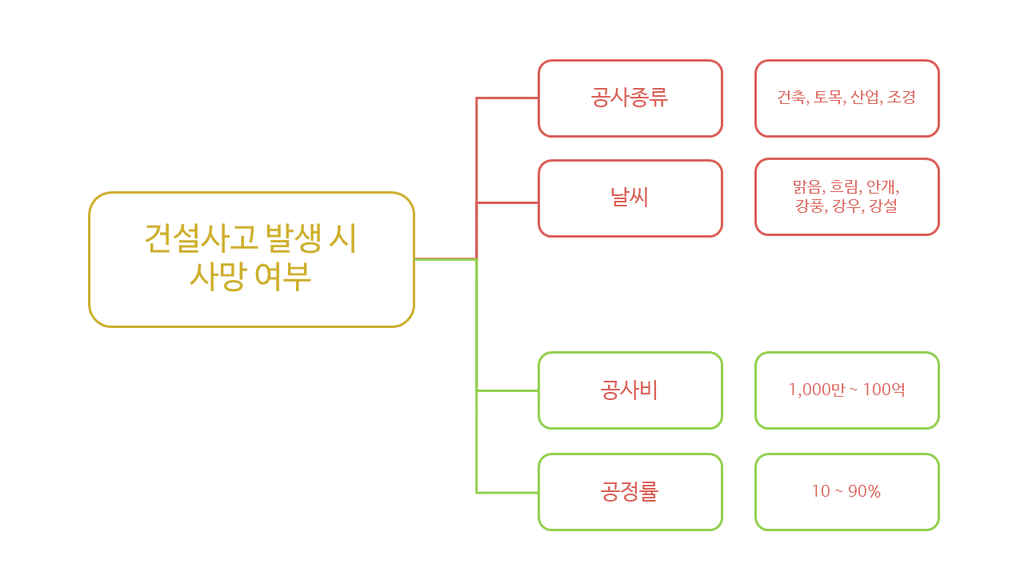

## 3-2. 한계 및 보완할 점

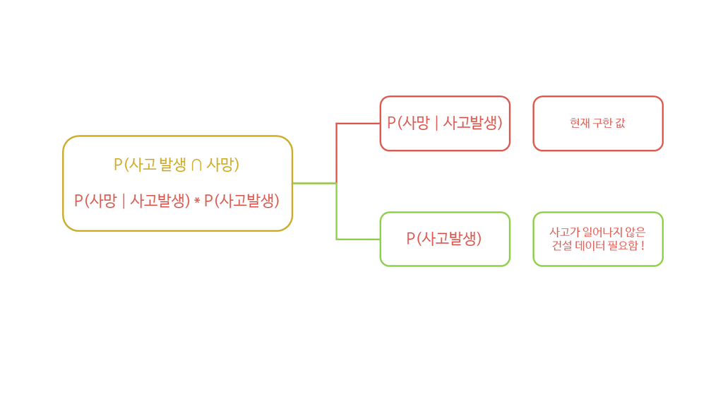

- 위 예측 모델은 전제조건으로 '건설사고가 발생하였을 때'가 필요함.
- 현재는 '건설 사고가 발생하였을 때, 사망 여부'를 예측하는 모델임. (조건부 확률)
- **건설사고가 일어나지 않은 경우의 데이터를 입력하여 건설 사고가 발생하고 사망할 확률을 파악하는 모델**로 보완해줄 필요가 있음.
- 공정율과 공사비를 제외한 독립변수들은 범주형 데이터임.**범주형 독립변수로 인해 항목이 세분화 되다 보니 각 계수의 유의미함이 떨어지게 나옴.**
- 공사비,공정율과 같은 수치형 독립변수가 많았다면 더 나은 예측모델이 나왔을 것으로 보임.

## 3-3. 시사점

- 공사비가 높아질수록 사망자 비율이 줄어드는 경향을 파악할 수 있었음.
- 아래 참고문헌 기사에는 **공사비는 건설사고 발생과 큰 연관성이 없다** 라고 밝힘.
- 위 두 사실을 종합하면 **공사비는 건설사고 발생 여부보다는 건설사고 발생 시, 사망 확률에 큰 영향을 미치므로 적정 공사비 확보가 중요하다** 라고 생각됨.

참고문헌 뉴스기사 http://www.newstof.com/news/articleView.html?idxno=798